# Banks Exploritory and Analysing

- Muneers Al Rashiad
- Nethar Al Otaibi
- Amna Burshid

# Introduction

Exploring the followers and user of three banks they are Boubyan Bank, Kuwait Financial House and National Bank of Kuwait, through their Twitter accounts after that analysing each bank

## Method Used

We chose Twitter to explore and analyze the data, tweepy was the tool to gather three banks for our project which were Boubyan bank, KFH and NBK, also another source added to gather Net Profit for each bank from (Bayanati.com) website

**We gathered three data for each bank:**

- Followers

  ```
    Each of the team member got a specific bank, and each gathered 50,000 rows and 28 columns
    We Combined the three dataframes under the column Bank Name
    The total rows that was gathered is 150,000 rows but we foundout there were 150,028 rows
    After clearing the 28 records the amount of the rows decresed
  ```

- User Timeline

  ```
    Each team member gathered 3,000+ rows and 15 columns
    Tweepy gave a limit number of tweets to collect
    It was a clean dataframe
  ```

- Get User

  ```
    Each bank got one row and 4 columns
  ```

## Null Issue:

# Notice how the null values are 28 in few columns

```
    contributors_enabled                 0
    created_at                          11
    description                     103282
    favourites_count                    28
    followers_count                     28
    friends_count                       28
    geo_enabled                         28
    id                                  28
    id_str                              28
    lang                                40
    listed_count                        28
    location                        105031
    name                                45
    profile_background_color            28
    profile_background_image_url    119970
    profile_background_tile             28
    profile_image_url                   28
    profile_text_color                  28
    profile_use_background_image        28
    protected                           28
    screen_name                         44
    statuses_count                      43
    time_zone                       139239
    url                             142275
    utc_offset                      139240
    verified                            45
    Bank_Name                            0
    dtype: int64
```

## Libararies

```
- Pandas
- Altair
- Matplotlip
- Numpy
```

# Results

- **Followers**

[output not shown]

- **User Timeline**

[output not shown]

- **Get User**

| Bank Name | Created_at | Name | Location |
| --- | --- | --- | --- |
| **KFH** | 09/09/2009 | Kuwait Financial House | Kuwait |
| **NBK** | 15/09/2009 | National Bank of Kuwait | Kuwait |
| **Boubyan** | 02/02/2010 | Boubyan Bank | Kuwait |

## Followers Inshight:

- we wanted to see the bank's followers created at accounts: **KFH Followers**

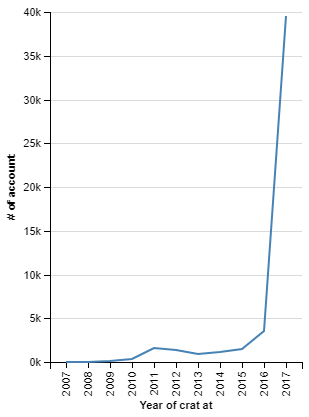

  **Boubyan Followers**

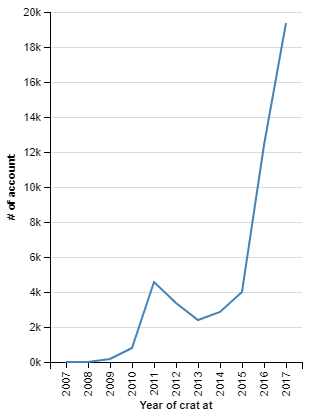

  **NBK Followers**

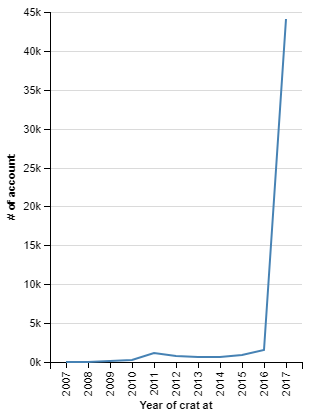

## Question:

- why 2017? because Tweepy downloads the last followers of each bank so it makes sense that these number occur.

### Notice:

- we looked into each column in the df to see if any unique data appears.

### Bank Boubyan Protected accounts:

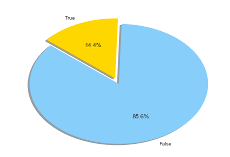

### Bank NBK Protected accounts

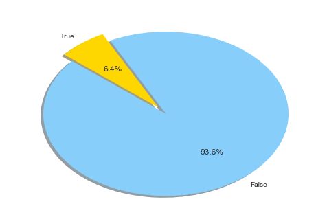

### Bank KFH Protected accounts

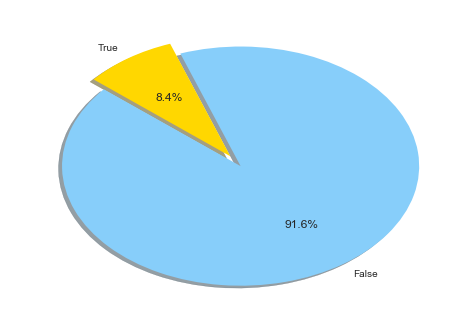

- by comparing the Protected accounts in each bank we notice that the first graph which is bank boubyan has the most followers with protected account than other bank's followers
- in terms of languages we notice that all banks have the most followers that use an arabic language in their devices second comes english and third is en-gb which is british english

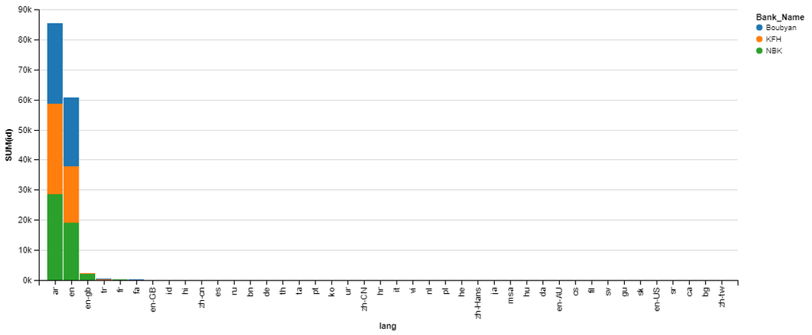

- we looked at the rare languages and we saw that most rare languages were found for the KFH followers

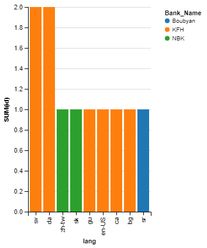

- by looking at the time_zones that were enabled to some not all followers of all banks we notice that the 3 banks that have the most followers that were present in kuwait and second is US & Canada third is Baghdad
- we also notice that bank boubyan which is the blue color has the most most followers that enabled that time zone in their accounts than the other banks.

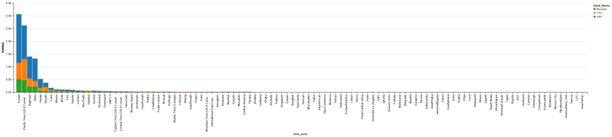

**Followers Description**

- in terms of description boubyan has the most followers that wrote their description

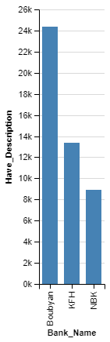

**followerlocation**

- also the location that users write for themselves are the highest for boubyan followers.

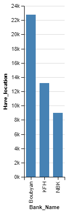

**followername**

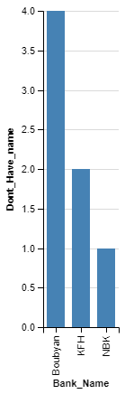

**followerBG1**

- by looking at the profile backgound colors we notice that boubyan followers have the most highest unqiue colors than the other banks

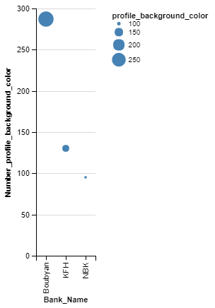

**FollowersBG2**

- we took the top colors and to see what were they F5F8FA is Light gray to white which is the default color for backrounds while C0DEED is Light blue.
- we wanted to see which accounts have the most deafult color

[figure not shown]

**bg_uniqu**

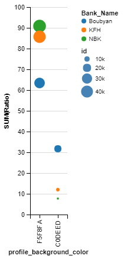

**conclusion for this graph:**

- since F5F8FA is the default color for a profile we notice that NBK followers have that color the most and close to it comes KFH while the least is boubyan we can conclude from this:
- changing this profile background color requires a PC not a mobile so this tells us that boubyan followers use PC the most to change their profile backghroud since in the graph above it says it's the most bank with unique colors is boubyan.
- NBK users are the least people who used a PC in any sort to change their background profile color while boubyan is the most.

### Followers that tweet the most:

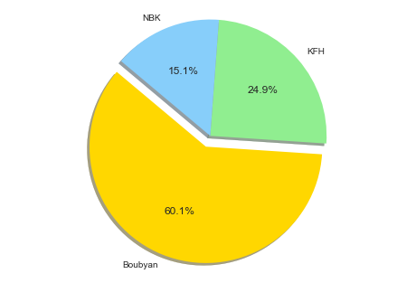

### Followers twitter activity:

**follower2017**

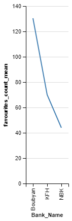

**follower2017-2**

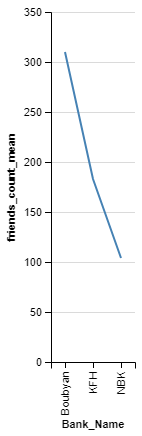

**follower2017-3**

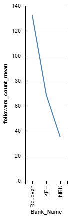

## Conclusion

- from these 3 graphs above we notice most activities lie with bank boubyan followers their followers have the most favoriates count and followers count and followings count whic tells us their followers are the most active.

## Question

- now that we saw bank boubyan followers are the most in terms of twitter activity, enabling locations and changing colors we want to know why? why are boubyan followers the most in having these activities than the other banks so in the next dataframe for the users we'll analyze the banks to see what's unique about bank boubyan accounts and what's difference in other accounts.

## Users Insights:

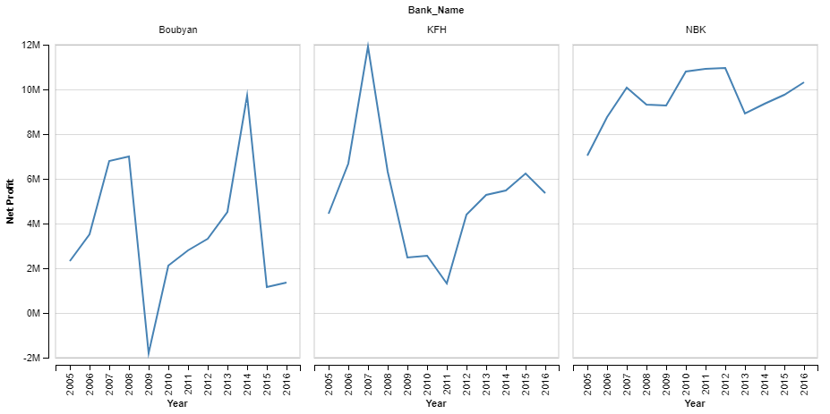

| Bank Name | Created_at | Name | Location |
| --- | --- | --- | --- |
| **KFH** | 09/09/2009 | Kuwait Financial House | Kuwait |
| **NBK** | 15/09/2009 | National Bank of Kuwait | Kuwait |
| **Boubyan** | 02/02/2010 | Boubyan Bank | Kuwait |

### Notices:

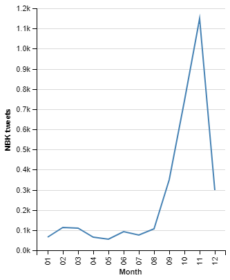

- Number of Boubyan Bank Tweets in a Month

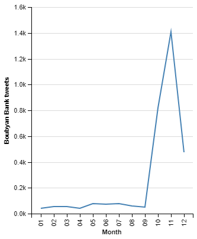

- Number of KFH Tweets in a Month

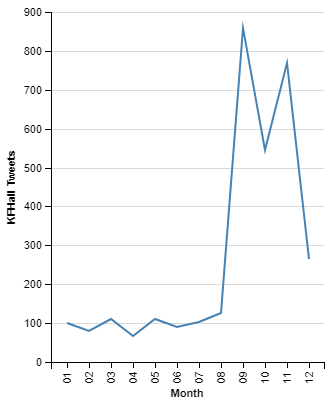

### Tweets Activity

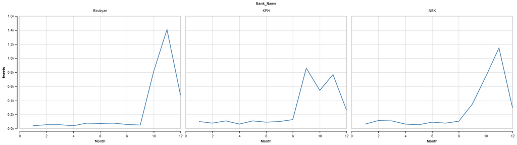

- we notice that each bank's tweet activity increase at the end of the months of the year and the highest of them all is boubyan tweeting the more 1K on november.

### Comparing to see which bank tweets the most during this year:

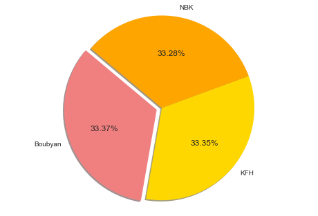

- we can notice that boubyan tweets more than the other by slighting a decimal which isn't a big deal.

### between those tweets which tweets gets more favorited by followers?

[figure not shown]

**Banks URLs**

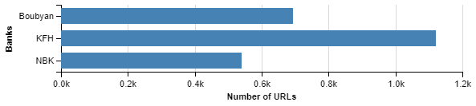

- from this graph we notice that the most bank that posts urls is KFH then boubyan and the last is NBK

### Banks that Reply to their followers the most:

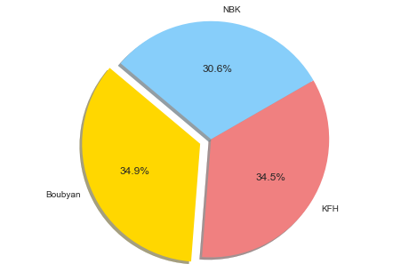

- again Boubyan and KFH are very close and similar while NBK is falling behind and don't interact much with their followers as much as the other banks.

### Banks that frequently use their hashtages the most:

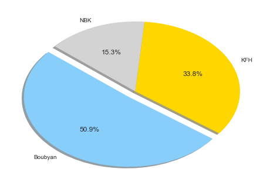

**Notice:**

- here is a signeficant notice that bank boubyan tweets the alot of their hashtags than the both 2 banks combined so we wanted to see which hashatges they tweet the most